# Analysis of EwS PDXs context-specific GEMs

## Analysis of EwS PDXs context-specific GEMs

After creation of the context-specific models (generated starting from the thermodynamically curated GEMs provided in Masid et al. 2020) we can proceed and analyze the models.

To do so, we need to provide the initial GEM name, the silhouette summary table, that’s needed to select the parameters for which clusters are better discriminated by their annotation as well as to locate the directories where results are stored, and the files containing the FBA profiles and the mapped gene expression to reactions.

```r
model.name = 'recon2_thermocurated' #just change model name to explore results on the other models

silhouette_summary <- read.csv(paste0("./cluster_info/pdx/", model.name,
                                      "/silhouette_summary.txt"), sep="")

## select the one for which the mean silhouette score is the max
sel = which.max(silhouette_summary[, "Mean"])
data.dir = paste0('./cluster_info/pdx/', paste(silhouette_summary[sel, 1:4], collapse = "/"))
silhouette_width <- read.csv(paste0(data.dir,"/silhouette_width_spca.txt"), sep="")

## read the cluster profiles :
pr <- paste0('./cluster_profiles/pdx/', paste(silhouette_summary[sel, 1:4],
                                                          collapse = "/"))

desc = unlist(strsplit(pr, split='pdx/'))

cp_dir = list.dirs("cluster_profiles")
FBA_dir = list.dirs("FBA_solution")
vtr_dir = list.dirs("ValToReact")
info_dir = list.dirs("cluster_info")

cp_dir = cp_dir[grepl('cl_aggregation_by_', cp_dir)]
FBA_dir = FBA_dir[grepl('cl_aggregation_by_', FBA_dir)]
vtr_dir = vtr_dir[grepl('cl_aggregation_by_', vtr_dir)]
info_dir = info_dir[grepl('cl_aggregation_by_', info_dir)]

FBA_fl = FBA_dir[grep(desc[2], FBA_dir)]
vtr_fl = vtr_dir[grep(desc[2], vtr_dir)]
info_fl = info_dir[grep(desc[2], info_dir)]

FBA_fn = list.files(paste0('./', FBA_fl))
vtr_fn = list.files(paste0('./', vtr_fl))
```

We can first have a look at the silhouette scores and visualize the data:

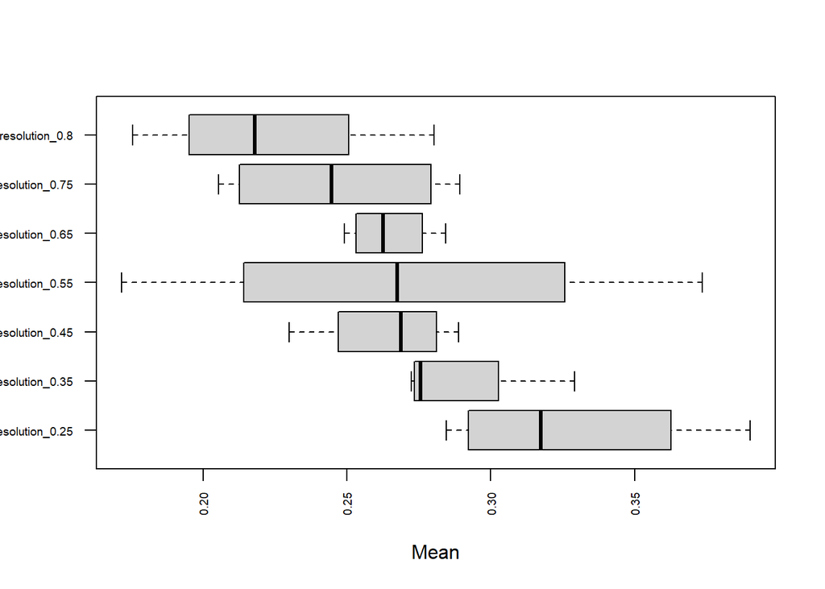

```r
boxplot(Mean ~ cl_resolution, data =silhouette_summary,
        las = 2, horizontal = TRUE, cex.axis=0.6, ylab="")
```

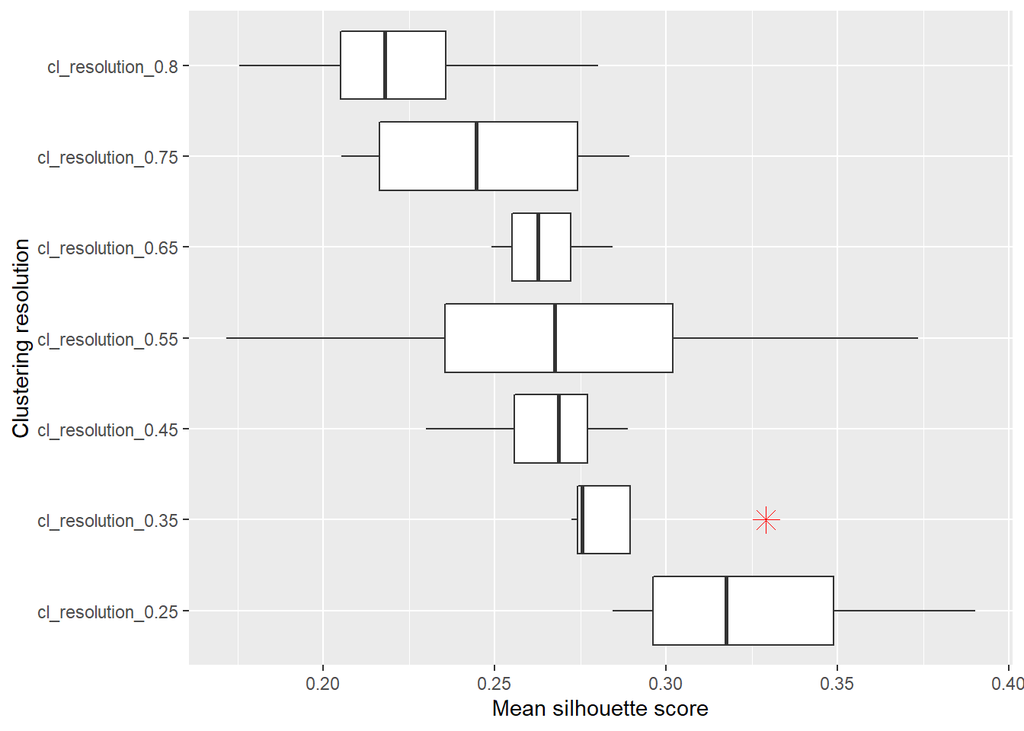

```r
p <- ggplot(silhouette_summary, aes(x=cl_resolution, y=Mean)) +
  geom_boxplot(outlier.colour="red", outlier.shape=8,
               outlier.size=4)
p + coord_flip()+labs(y="Mean silhouette score", x="Clustering resolution")
```

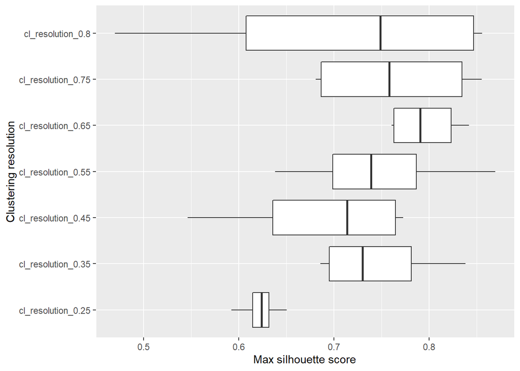

```r
p <- ggplot(silhouette_summary, aes(x=cl_resolution, y=Max.)) +
  geom_boxplot(outlier.colour="red", outlier.shape=8,
               outlier.size=4)
p + coord_flip()+labs(y="Max silhouette score", x="Clustering resolution")
```

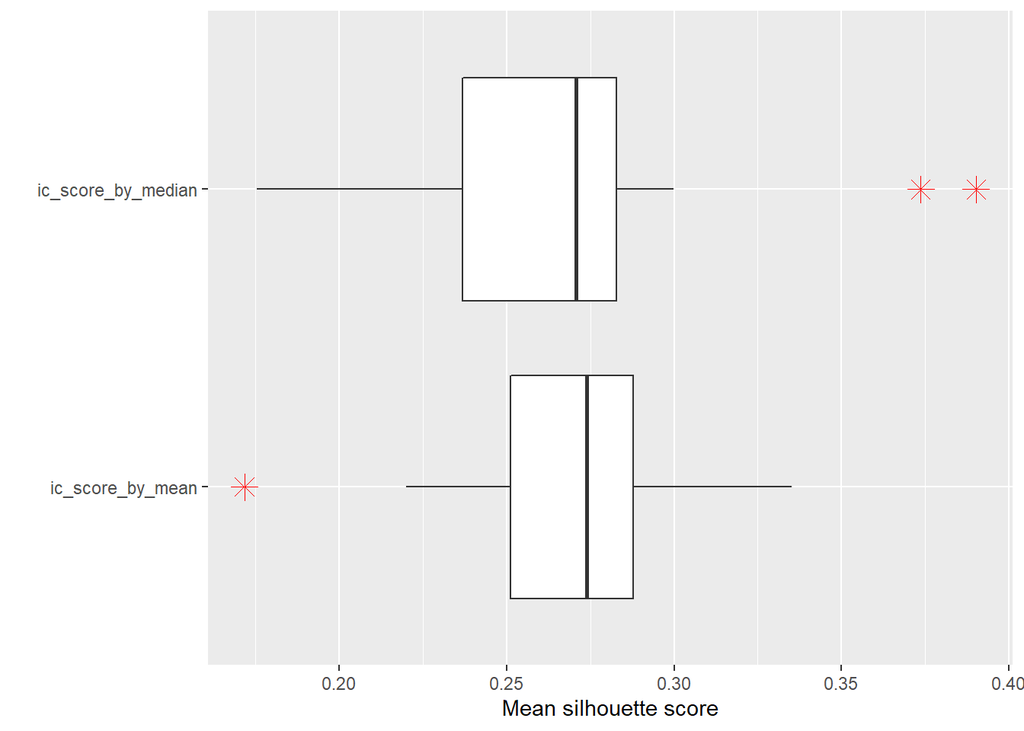

```r
p <- ggplot(silhouette_summary, aes(x=ic_score_by, y=Mean)) +
  geom_boxplot(outlier.colour="red", outlier.shape=8,
               outlier.size=4)
p + coord_flip()+ labs(x="", y="Mean silhouette score")
```

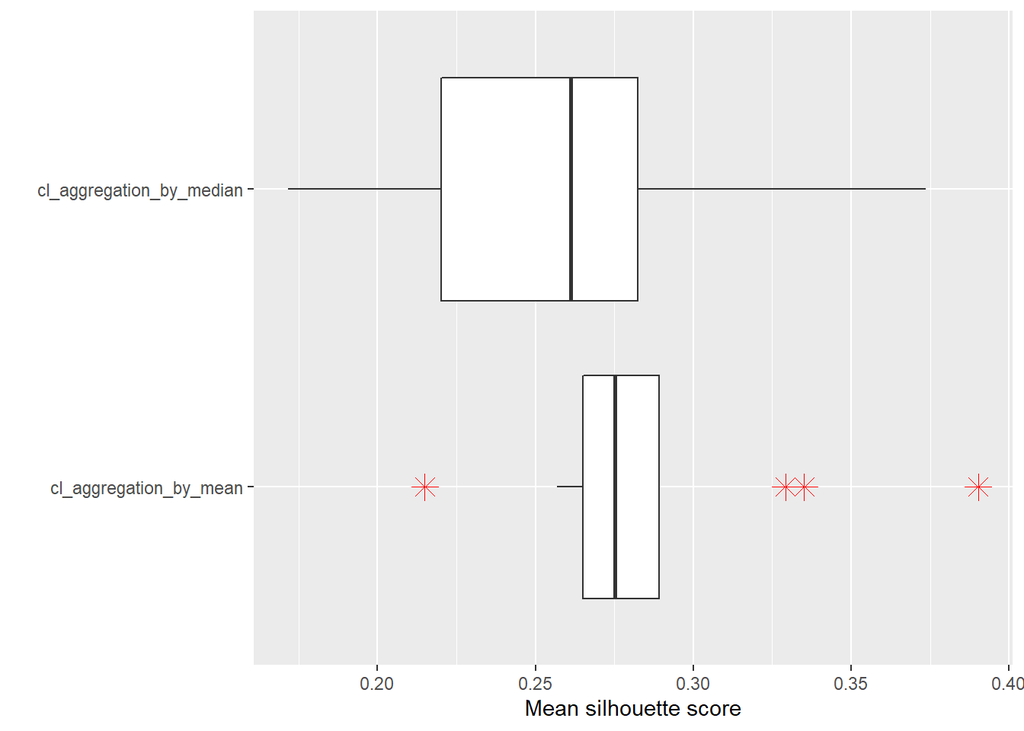

```r
p <- ggplot(silhouette_summary, aes(x=cl_aggregation_by, y=Mean)) +
  geom_boxplot(outlier.colour="red", outlier.shape=8,
               outlier.size=4)
p + coord_flip()+ labs(x="", y="Mean silhouette score")
```

And construct some aesthetics:

```r
pdxName = unlist(lapply(strsplit(rownames(pdxScores), split="\\."), function(x) x[1]))
names(pdxName) = unlist(lapply(strsplit(pdxName, split = '_'), function(x) return(x[1])))
pdxCol = colors_signature(names(pdxName))
try_classification = sd_compare(pdxScores)
class.labels = apply(try_classification, 1, myclassification)
class.labels = check.classification(class.labels, pdxScores)
col.sign = colors_signature(class.labels)
table(class.labels)
```

```
## class.labels
##                                                _Average
##                                                      29
##                                               _Ews_high
##                                                      10
##                               _Ews_high_Glucose/Hypoxia
##                                                       2
## _Ews_high_Proliferating_Glucose/Hypoxia_Redox/OxPhosPho
##                                                       2
##                                                _Ews_low
##                                                      11
##          _Proliferating_Glucose/Hypoxia_Redox/OxPhosPho
##                                                       6
##                          _Proliferating_Redox/OxPhosPho
##                                                       9
##                                        _Redox/OxPhosPho
##                                                       3
```

Now we are ready to visualize our classification:

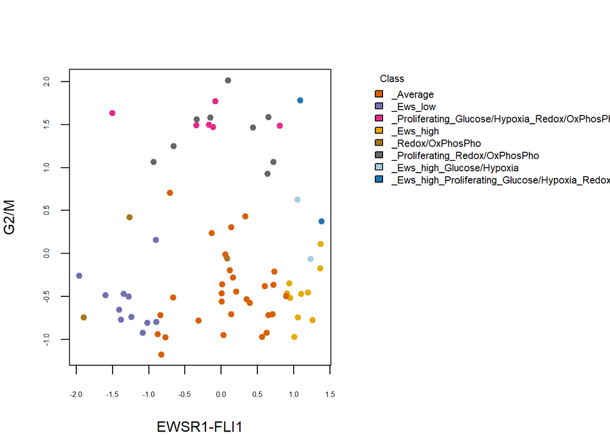

```r
par(mar=c(4,4,4,16), xpd = TRUE)
plot(pdxScores$ic10_plus, pdxScores$ic1_plus, col=col.sign[class.labels],
     pch=19, xlab= "EWSR1-FLI1", ylab="G2/M", cex.axis= 0.5, cex= 0.9)
legend("topright", legend = names(col.sign), inset = c(-1.3,0),
       fill=col.sign, cex=0.7, title = "Class", bty='n', xjust = 0,
       yjust = 0, title.adj = 0.05)
```

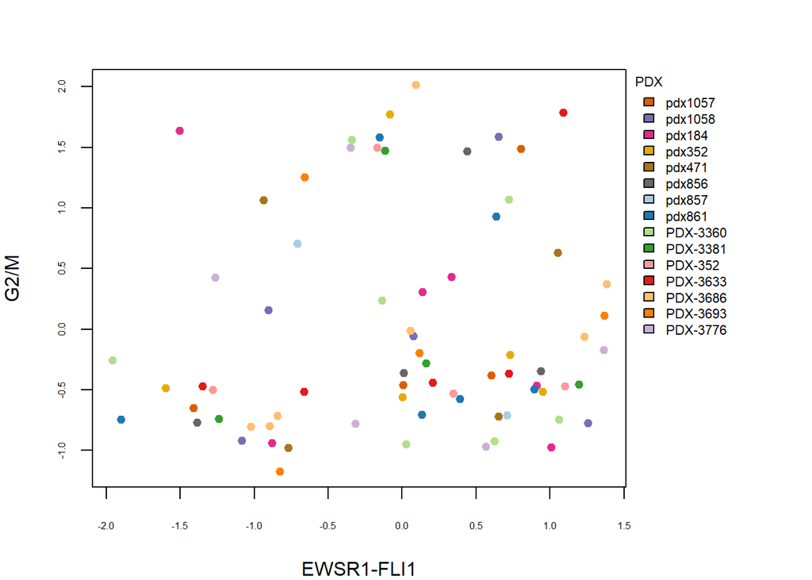

```r
par(mar=c(4,4,3,8), xpd = TRUE)
plot(pdxScores$ic10_plus, pdxScores$ic1_plus, col=pdxCol[names(pdxName)],
     pch=19, xlab= "EWSR1-FLI1", ylab="G2/M", cex.axis= 0.5,  cex= 0.9)
legend("topright", legend = names(pdxCol), inset = c(-0.2,0),
       fill=pdxCol, cex=0.7, title = "PDX", bty='n', xjust = 0,
       yjust = 0, title.adj = 0.05)
```

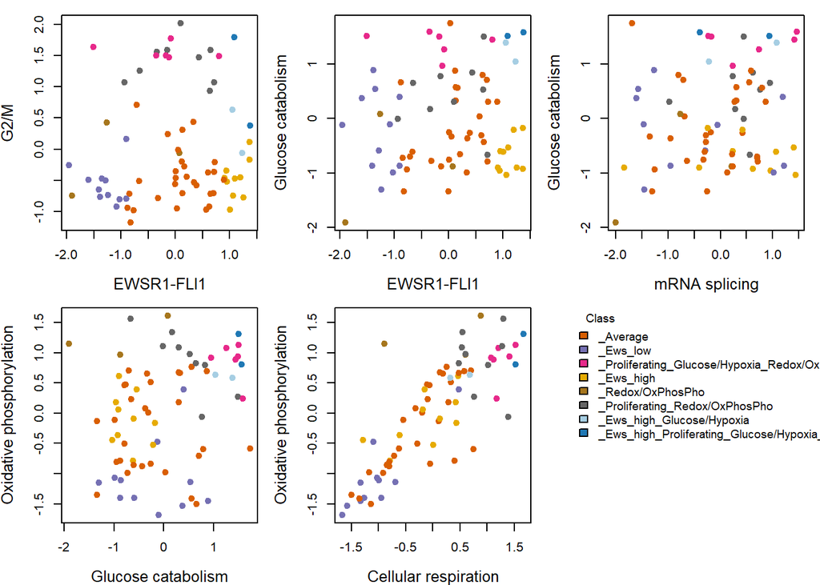

```r
par(mfrow=c(2,3), mar =c(4,4,1,1))
pc = 1
plot(pdxScores$ic10_plus, pdxScores$ic1_plus, col=col.sign[class.labels],
     pch=19, xlab= "EWSR1-FLI1", ylab="G2/M",
     cex =pc, cex.lab=1.25)
plot(pdxScores$ic10_plus, pdxScores$ic14_plus, col=col.sign[class.labels],
     pch=19, xlab= "EWSR1-FLI1", ylab="Glucose catabolism",
     cex=pc, cex.lab=1.25)
plot(pdxScores$ic9_plus, pdxScores$ic14_plus, col=col.sign[class.labels],
     pch=19, xlab= "mRNA splicing", ylab="Glucose catabolism",
     cex=pc, cex.lab=1.25)
plot(pdxScores$ic14_plus, pdxScores$ic6_plus, col=col.sign[class.labels],
     pch=19, ylab= "Oxidative phosphorylation", xlab="Glucose catabolism",
     cex=pc, cex.lab=1.25)
plot(pdxScores$ic4_plus, pdxScores$ic6_plus, col=col.sign[class.labels],
     pch=19, ylab= "Oxidative phosphorylation", xlab="Cellular respiration",
     cex=pc, cex.lab=1.25)
par(xpd=TRUE)
plot(x=0, y=0, type='n', axes = FALSE, ylab="", xlab="")
legend("topleft",
       legend = names(col.sign),
       fill=col.sign, inset = c(-0.2,0),
       cex=0.9, title = "Class", bty='n', xjust = 0,
       yjust = 0, title.adj = 0.05)
```

Once we have the cluster classification, we can coherce to a unique matrix the FBA profiles:

```r
reaction.names = lapply(FBA_profiles, row.names)
reaction.names = unique(do.call(c, reaction.names))
FBA_profiles_ordered = lapply(FBA_profiles, function(x){
  fl.matrix = matrix(NA, nrow = length(reaction.names), ncol=1)
  rownames(fl.matrix) = reaction.names
  fl.matrix[rownames(x), ] <- as.matrix(x)
  return(fl.matrix)
})
FBA_profile_matrix = do.call(cbind, FBA_profiles_ordered)
colnames(FBA_profile_matrix) = paste(cluster_info$PDX, cluster_info$Cluster,
                                     sep='_')
sel.pdx = c(grep("pdx", colnames(FBA_profile_matrix)),
            grep("PDX", colnames(FBA_profile_matrix)))
FBA_profile_matrix = FBA_profile_matrix[, sel.pdx]

data.Matrix = t(FBA_profile_matrix)
data.Matrix = as.data.frame(data.Matrix)

## remove constant fluxes
v0 = apply(data.Matrix, 2, var, na.rm = TRUE)
data.Matrix = data.Matrix[, -which(v0==0)]
```

As first check we can wonder if clusters with the same annotation also have the same reactions turned off. Note that we have already removed reactions with constant zero flux from the FBA profile matrix.

```r
classes = unique(class.labels)
per_class_rxns_off = list()
data_per_class = list()
for (cl in classes){
  sel.cl = which(cl ==class.labels)
  data.cl = data.Matrix[names(sel.cl), ]
  nrb = apply(data.cl, 2, function(rxns){
    number_reaction_is_blocked = length(which(is.na(rxns)))
    return(number_reaction_is_blocked)
  })
  prop_nrb_in_class = nrb/length(sel.cl)
  rxns_off = prop_nrb_in_class[order(prop_nrb_in_class, decreasing = TRUE)]
  ## Select just those reactions that are off in all clusters from the class
  rxns_off = names(rxns_off[which(rxns_off==1)])
  per_class_rxns_off[[cl]] = rxns_off
  rxns_off = NULL
  data_per_class[[cl]] = data.cl
}
lengths(per_class_rxns_off)
```

```
##                                                _Average
##                                                     229
##                                                _Ews_low
##                                                     424
##          _Proliferating_Glucose/Hypoxia_Redox/OxPhosPho
##                                                     596
##                                               _Ews_high
##                                                     494
##                                        _Redox/OxPhosPho
##                                                     605
##                          _Proliferating_Redox/OxPhosPho
##                                                     497
##                               _Ews_high_Glucose/Hypoxia
##                                                     579
## _Ews_high_Proliferating_Glucose/Hypoxia_Redox/OxPhosPho
##                                                     804
```

```r
per_class_rxns_off
```

```
## $`_Average`
##   [1] "3SPYRSPm"
##   [2] "EX_for_e"
##   [3] "EX_gluala_e"
##   [4] "EX_glyc_S_e"
##   [5] "EX_h_e"
##   [6] "GLYC_St"
##   [7] "EX_carn_e"
##   [8] "EX_sfcys_e"
##   [9] "SFCYSc"
##  [10] "SFCYSe"
##  [11] "4MOPte"
##  [12] "EX_4mop_e"
##  [13] "CHOLt4"
##  [14] "DMNONCOACRNCPT1"
```

[output cut: 4228 more lines]

Let’s visualize the results:

```r
library("ggVennDiagram")
if (length(per_class_rxns_off)<7){
  p = ggVennDiagram(per_class_rxns_off,
              edge_lty="dashed", label = "count",
              label_alpha = 0.1,
              )
  p+ scale_fill_distiller(palette =  'RdBu')
}
library("tidyverse")
unique.off.react.per.class = data.frame(data = names(per_class_rxns_off), number = matrix(per_class_rxns_off)) %>% tidyr::unnest(cols = c(number))
unique.elem = which(table(unique.off.react.per.class$number) == 1)
pos.unique.ele = lapply(names(unique.elem), function(x) {which(x==unique.off.react.per.class$number)})
df = cbind(unique.off.react.per.class[unlist(pos.unique.ele), ], reaction_subsystem[names(unique.elem), ]$Subsystem)
colnames(df) = c("Class", "Reaction", "Subsystem")
```

We can also think about understanding what are the metabolic pathways involved:

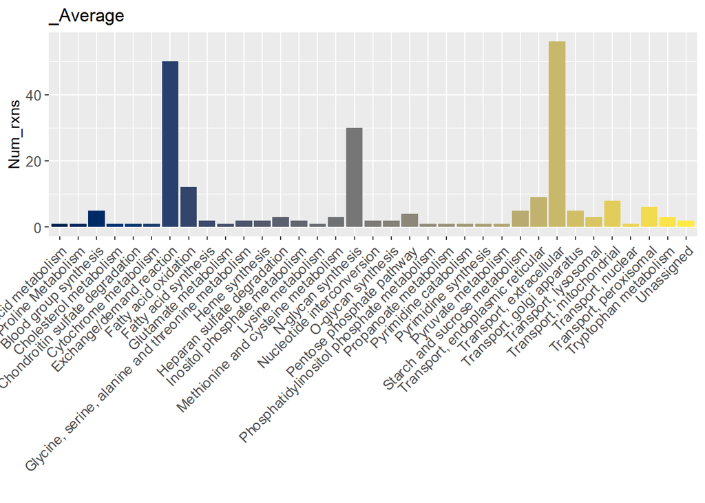

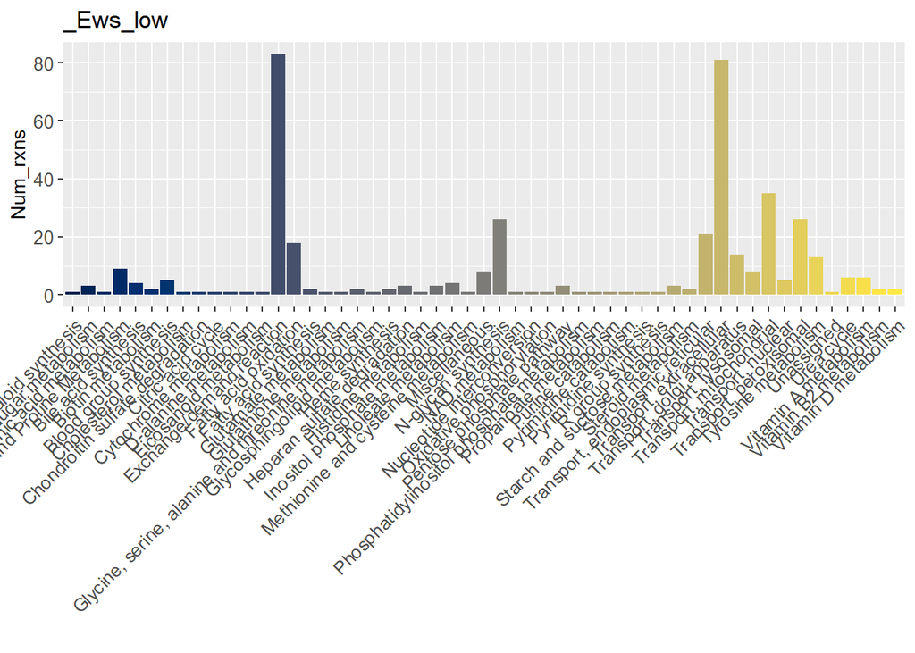

```
##
## $`_Proliferating_Glucose/Hypoxia_Redox/OxPhosPho`
```

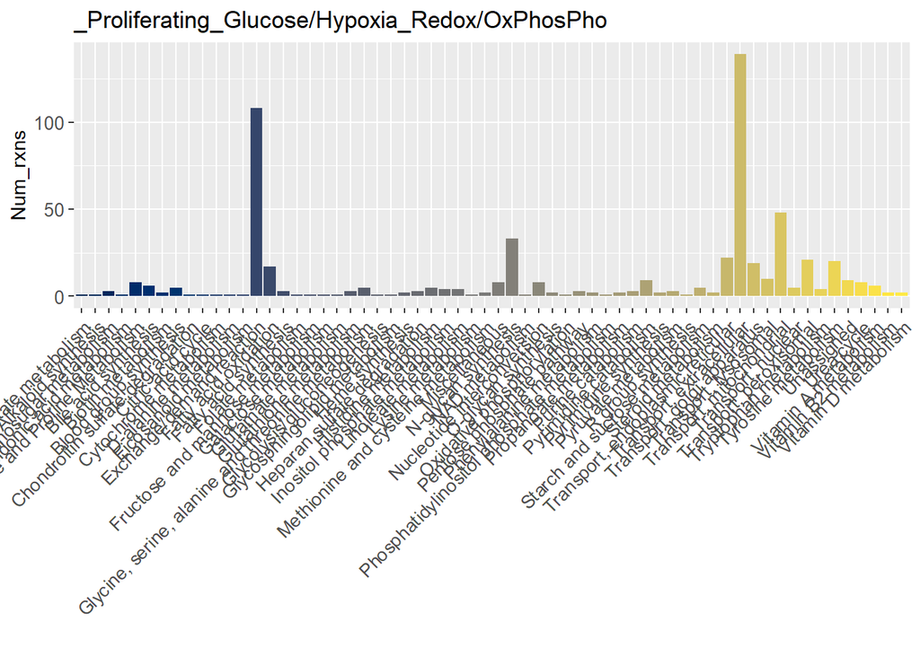

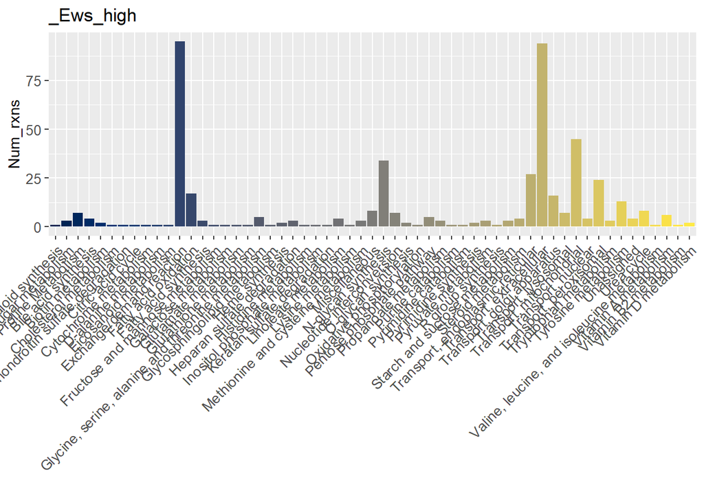

```
##
## $`_Redox/OxPhosPho`
```

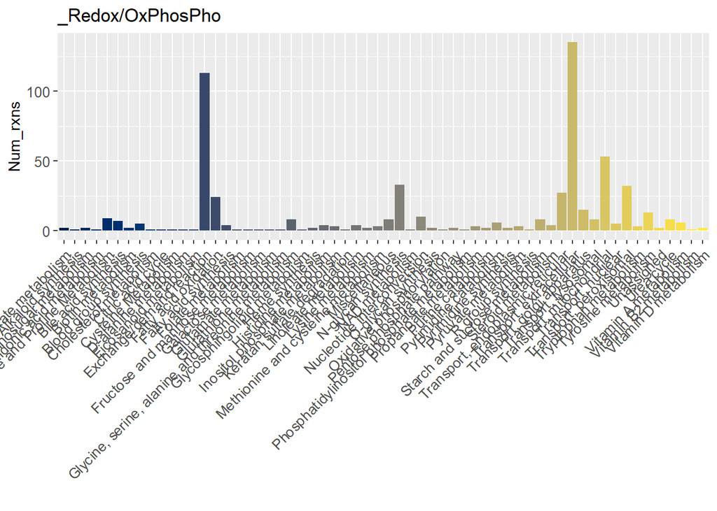

```
##
## $`_Proliferating_Redox/OxPhosPho`
```

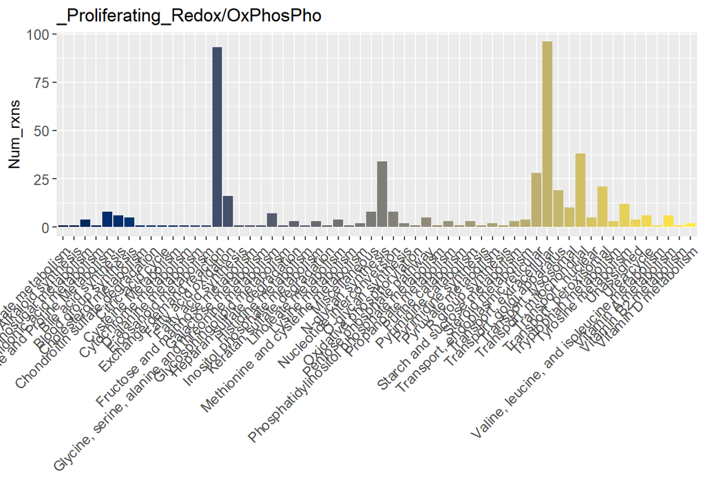

```
##
## $`_Ews_high_Glucose/Hypoxia`
```

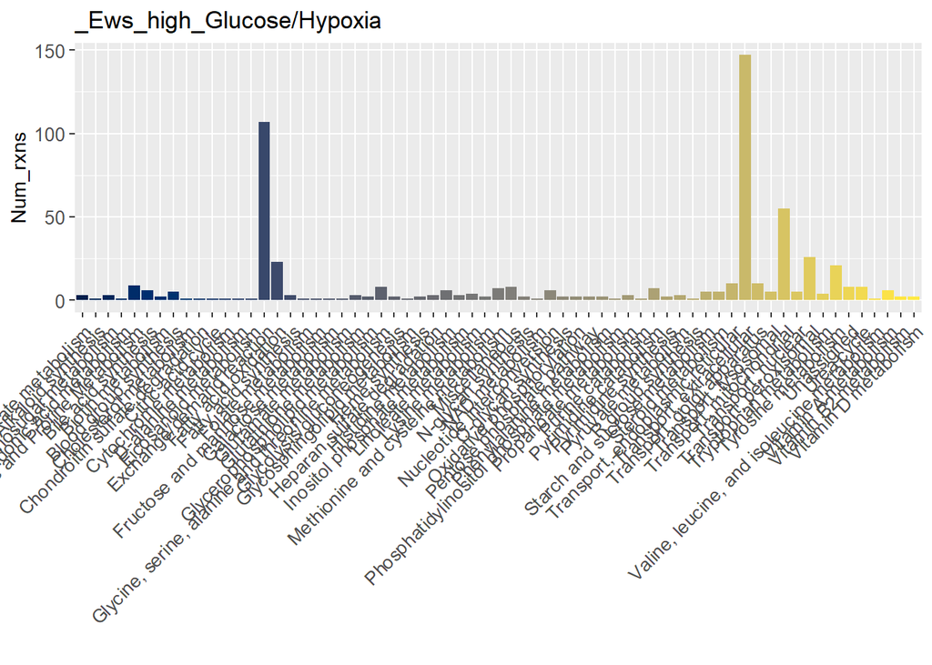

```
##
## $`_Ews_high_Proliferating_Glucose/Hypoxia_Redox/OxPhosPho`
```

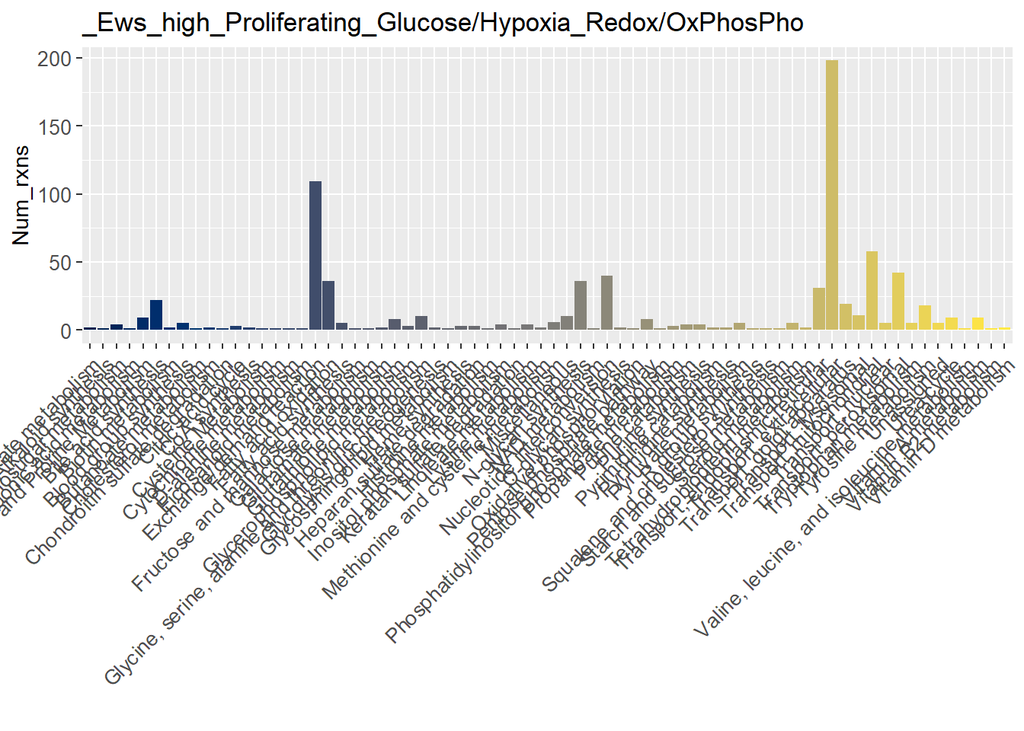

```r
library(data.table)
library(ggplot2)
library(viridis)
library(hrbrthemes)
ncl = length(classes)
tab_subsystem_off = list()
p = list()
for (cl in classes){
  tab_subsystem_off[[cl]] = t(table(reaction_subsystem[per_class_rxns_off[[cl]], 'Subsystem']))
  rownames(tab_subsystem_off[[cl]]) = cl
  tab_subsystem_off[[cl]] = as.data.frame(tab_subsystem_off[[cl]])
  colnames(tab_subsystem_off[[cl]]) = c("Class", "Subsystem", "Num_rxns")
  p[[cl]] <- ggplot(tab_subsystem_off[[cl]], aes(fill=Subsystem, y= Num_rxns, x = Subsystem))+
  geom_bar(position = "dodge", stat="identity") +
  scale_fill_viridis(discrete = T, option = 'E') +
  ggtitle(cl) +
  theme(legend.position='none', axis.text.x = element_text(angle = 45, hjust=1), axis.text = element_text(size = 10)) + xlab("")
  p[[cl]]
}
tab_subsystem = rbindlist(tab_subsystem_off, use.names=TRUE, fill= TRUE)
colnames(tab_subsystem) = c("Class", "Subsystem", "Frequency")
p
```

In addition to analyzing the set of context-specific models as implemented by the pipeline, we may like to gain in robustness of the observations by compairing what are the reactions which discriminate class annotation accross models and parameters (even in the worst scenario where the silhouette score is the min).

We first load the file cluster_and_correlated_reactions.txt generated while computing the silhouette scores. In practice, we associated reactions to Classes by: 1. We consider group centers in the spca space 2. A group was associated to a SPA component if its center was greater (or smaller in the negative direction) than any other 3. Each SPA component is explained by a set of reactions. We computed the standard deviation (sd) of the loadings, for each SPA and we associated to each component those reactions with a loading greater (or smaller in the negative direction) to 1.98sd.

```r
react_table <- read.csv(paste0("./cluster_info/pdx/", model.name,
                               "/clusters_and_correlated_reactions.txt"), sep="",
                        row.names = NULL)
colnames(react_table)[1] <- "Reactions"
react_table$SubSystem = reaction_subsystem[react_table$Reactions, ]$Subsystem

react_table <- as.data.frame(react_table)
classes = unique(react_table$Annotation)
rxns = lapply(classes, function(css){
  rxns = react_table$Reactions[which(react_table$Annotation == css)]
  rxns = table(rxns)[order(table(rxns), decreasing = TRUE)][1:10]
  return(rxns)
})
names(rxns) = classes
summary.table = lapply(classes, function(cl){
  rx = names(rxns[[cl]])
  cn = rxns[[cl]]
  return(cbind(rx, cn, rep(cl, length(rx))))
} )
summary.table = do.call(rbind, summary.table)
summary.table = cbind(summary.table, reaction_subsystem[summary.table[, "rx"], "Subsystem" ])
colnames(summary.table) <- c("Reactions", "Counts", "Class", "Subsystem")
head(as.data.frame(summary.table))
```

```
##                   Reactions Counts            Class
## FAOXC1811602m FAOXC1811602m      6 _Redox/OxPhosPho
## r0909                 r0909      6 _Redox/OxPhosPho
## VACCCPT1           VACCCPT1      6 _Redox/OxPhosPho
## VACCCPT2           VACCCPT2      6 _Redox/OxPhosPho
## VACCCRNt           VACCCRNt      6 _Redox/OxPhosPho
## MMCDm                 MMCDm      5 _Redox/OxPhosPho
##                                                Subsystem
## FAOXC1811602m                       Fatty acid oxidation
## r0909                   Transport, endoplasmic reticular
## VACCCPT1                            Fatty acid oxidation
## VACCCPT2                            Fatty acid oxidation
## VACCCRNt                            Fatty acid oxidation
## MMCDm         Valine, leucine, and isoleucine metabolism
```

Now consider the best case:

```r
data.Matrix[is.na(data.Matrix)] = 0 # set the blocked reactions to 0
# remove constant reactions
v0 = apply(data.Matrix, 2, var)
data.Matrix = data.Matrix[, -which(v0==0)]

silhouette_summary = perform_spca_and_silhouette(class.labels, # classification
                                                   data.Matrix, # FBA flux matrix
                                                   info.fl, # directory to store silhouette scores
                                                   col.sign,
                                                   silhouette_summary, reaction_subsystem
                                                   )
```

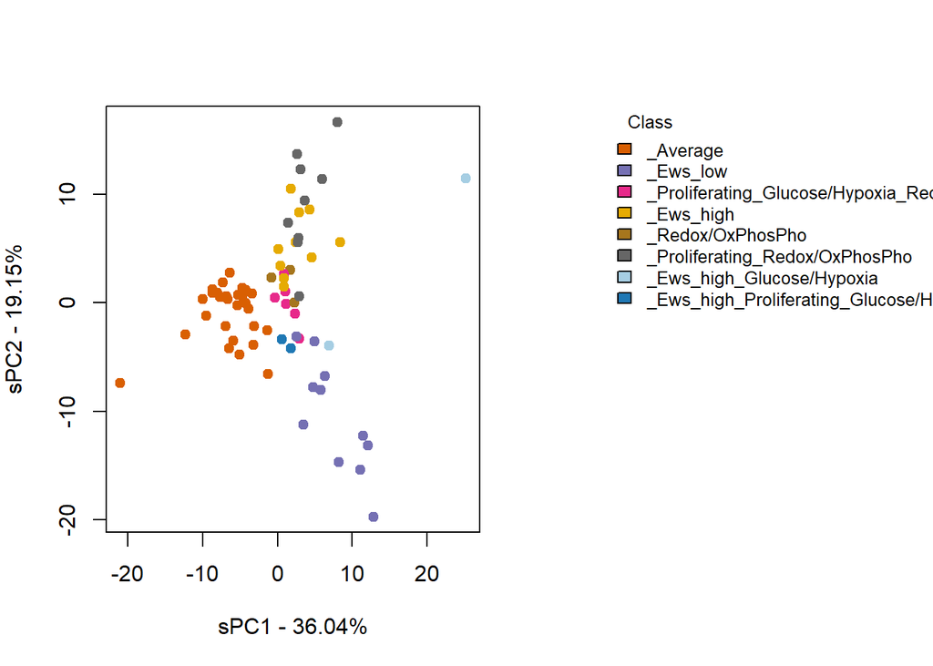

```r
react_table = silhouette_summary$react_table
colnames(react_table) = c("loadings", "Annotation")
silhouette_summary = silhouette_summary$silhouette_summary
```

```r
silhouette_summary = perform_spca_and_silhouette(class.labels, # classification
                                                   data.Matrix, # FBA flux matrix
                                                   info.fl, # directory to store silhouette scores
                                                   col.sign,
                                                   silhouette_summary, reaction_subsystem,
                                                 dims = c(3,4)
                                                   )
```

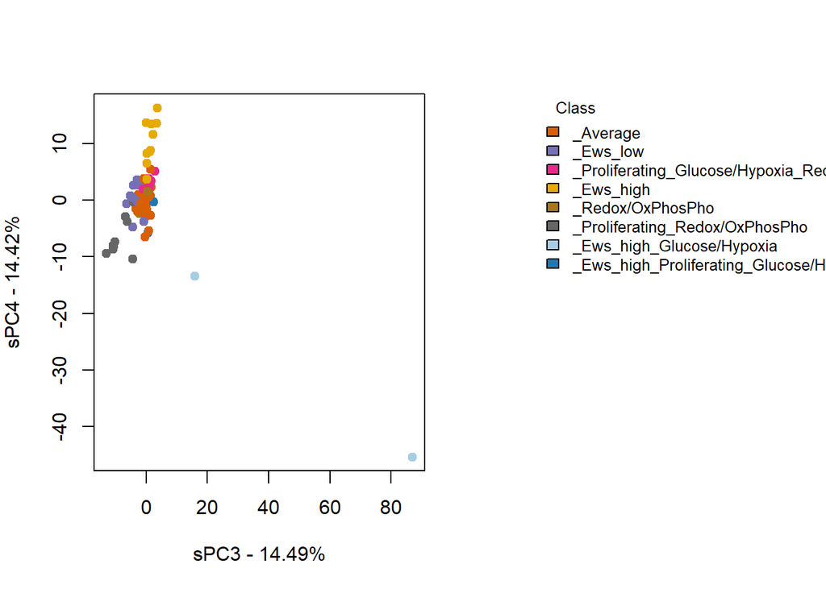

```r
react_table = silhouette_summary$react_table
colnames(react_table) = c("loadings", "Annotation")
silhouette_summary = silhouette_summary$silhouette_summary
silhouette_summary = perform_spca_and_silhouette(class.labels, # classification
                                                   data.Matrix, # FBA flux matrix
                                                   info.fl, # directory to store silhouette scores
                                                   col.sign,
                                                   silhouette_summary, reaction_subsystem,
                                                 dims = c(5,6)
                                                   )
```

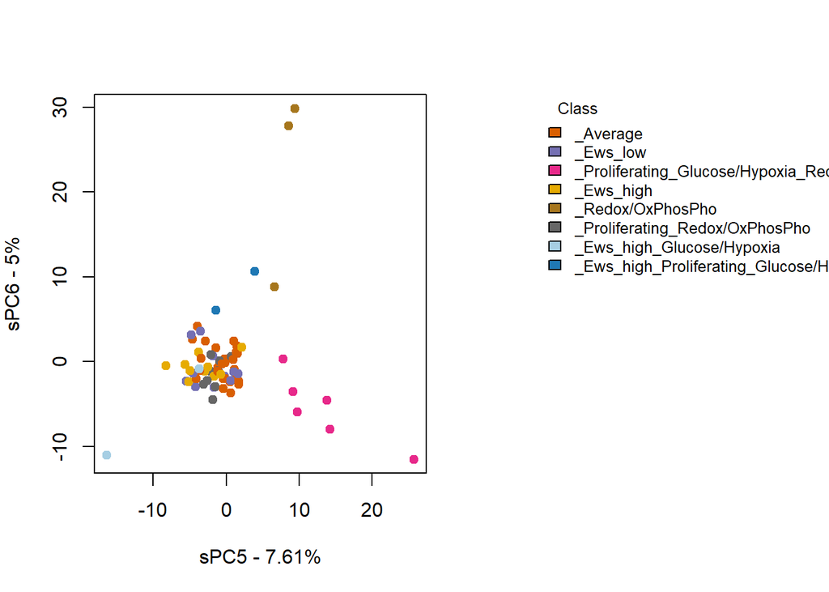

Let’s have a look to the reactions associated to the top 5 sPC components (loadings > 2*sd):

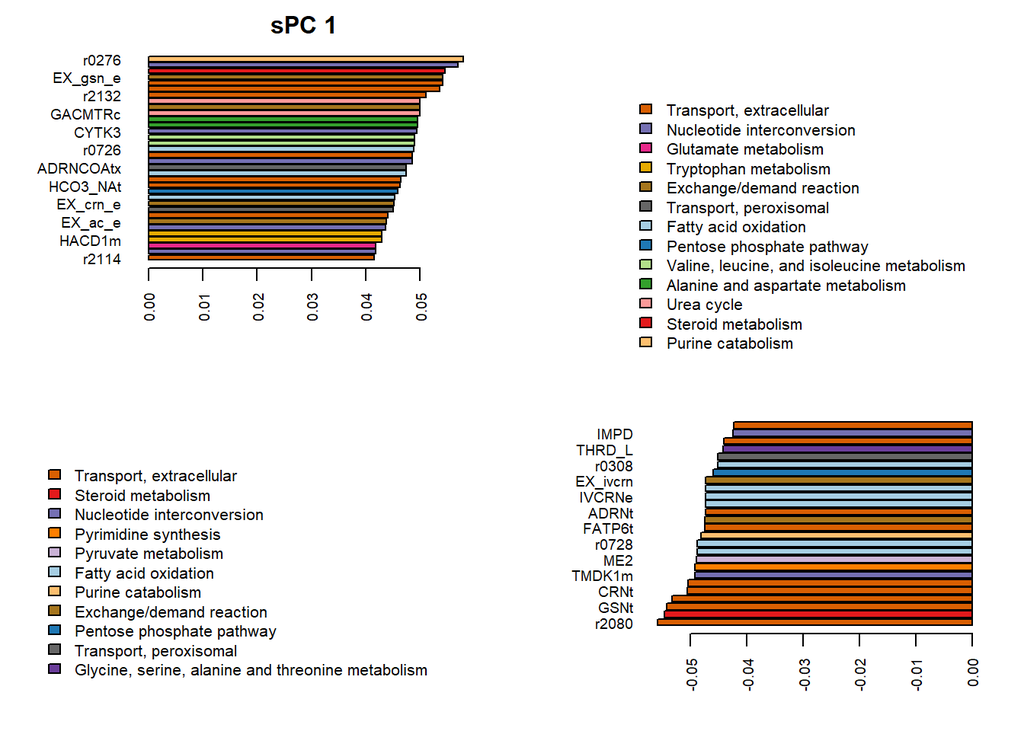

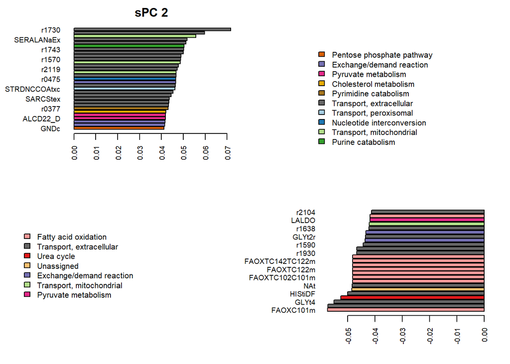

[figure not shown]

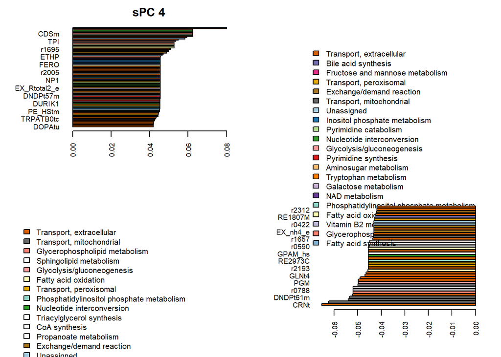

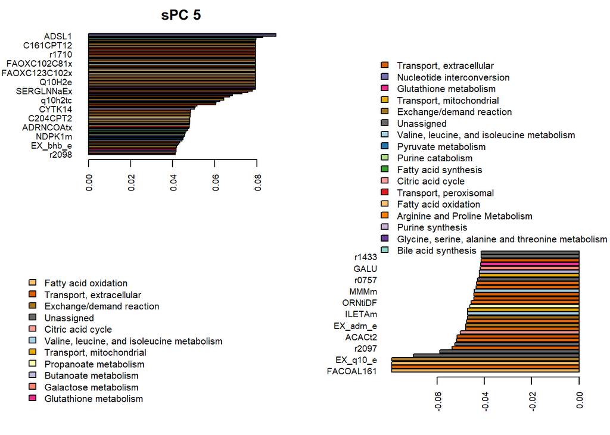

```r
spca.res = tsiMisc::spca(x = data.Matrix, y = class.labels, center = TRUE,
                         scale = TRUE, retx = TRUE)
react_table = NULL
for (pci in 1:5){
    react_table_pci = plot_corr_reactions(spca.res, threshold = NULL, pci,
                        reaction_subsystem, react_table = TRUE,
                        class.labels = class.labels)
    react_table = rbind(react_table, react_table_pci)
}
```